# Project 1 - Exploratory Data Analysis in R

Łukasz Kobyłecki (127292), Tomasz Gil (127295)

2-12-2019

## Data description

We have used a data set from Kaggle, available under the following link: https://www.kaggle.com/kemical/kickstarter-projects?fbclid=IwAR2xYRsLXeEKvpLpuQ7ONYRzUZsg5keYoskL6BGS29Do1f5tscFmcv40szo.

The data set aggregates information about most recent Kickstarter projects. Kickstarter is an crowdfunding website with projects of various size. Within the data set we have access to following attributes:

- ID: internal kickstarter id
- name: name of project - a project is a finite work with a clear goal that you’d like to bring to life (albums, books, or films)
- category: category
- main_category: category of campaign
- currency: currency used to support
- deadline: deadline for crowdfunding
- goal: fundraising goal - the funding goal is the amount of money that a creator needs to complete their project
- launched: date launched
- pledged: amount pledged by “crowd”
- state: Current condition the project is in
- backers: number of backers
- country: country pledged from
- usd pledged: amount of money pledged Goal amount in USD

## Preprocessing

First of all, we have to import packages.

```r
library("dplyr")
library("ggplot2")
library("scales")
library("Hmisc")
```

Then we read file and show sample data.

```r
data <- read.csv(file="data/ks-projects.csv", header=TRUE, sep=",")
head(data, 3)
```

```
##           ID                                              name
## 1 1000002330                   The Songs of Adelaide & Abullah
## 2 1000004038                                    Where is Hank?
## 3 1000007540 ToshiCapital Rekordz Needs Help to Complete Album
##         category main_category currency            deadline  goal
## 1         Poetry    Publishing      GBP 2015-10-09 11:36:00  1000
## 2 Narrative Film  Film & Video      USD 2013-02-26 00:20:50 45000
## 3          Music         Music      USD 2012-04-16 04:24:11  5000
##              launched pledged  state backers country usd.pledged X X.1 X.2
## 1 2015-08-11 12:12:28       0 failed       0      GB           0
## 2 2013-01-12 00:20:50     220 failed       3      US         220
## 3 2012-03-17 03:24:11       1 failed       1      US           1
##   X.3
## 1  NA
## 2  NA
## 3  NA
```

There are some columns, which are not necessary for the purpose of this analysis.

```r
colnames(data)
```

```
##  [1] "ID"            "name"          "category"      "main_category"
##  [5] "currency"      "deadline"      "goal"          "launched"
##  [9] "pledged"       "state"         "backers"       "country"
## [13] "usd.pledged"   "X"             "X.1"           "X.2"
## [17] "X.3"
```

Then we have to check if all data is correct. We check if there are NA values.

```r
for (i in colnames(data)) {
  print(paste(i, ": ", length(na.omit(data$main_category)), "/", length(data$main_category), sep = ""))
}
```

```
## [1] "ID: 323750/323750"
## [1] "name: 323750/323750"
## [1] "category: 323750/323750"
## [1] "main_category: 323750/323750"
## [1] "currency: 323750/323750"
## [1] "deadline: 323750/323750"
## [1] "goal: 323750/323750"
## [1] "launched: 323750/323750"
## [1] "pledged: 323750/323750"
## [1] "state: 323750/323750"
## [1] "backers: 323750/323750"
## [1] "country: 323750/323750"
## [1] "usd.pledged: 323750/323750"
## [1] "X: 323750/323750"
## [1] "X.1: 323750/323750"
## [1] "X.2: 323750/323750"
## [1] "X.3: 323750/323750"
```

Now we have to check if data is valid in all columns. 1. There are a lot of categories with just a few projects for each of them.

```r
as.vector(table(data$main_category))[1:30]
```

```
##  [1]     1     1     1     1     1     1     1     1     1     1     1
## [12]     1     1     3     2     1     2    10     7     3 23975    10
## [23]     1     2    18     1     4     2  8753     5
```

2. There are some invalid date values in ‘deadline’ columns.

```r
is.date <- function(x) !is.na(as.Date(x, format="%Y-%m-%d"))

deadlineDates <- as.character(factor(unique(data$deadline)))
deadlineDates[!is.date(deadlineDates)][1:10]
```

```
##  [1] "SEK"        "USD"        "GBP"        "Music"      "Crafts"
##  [6] "CAD"        "SGD"        "EUR"        "AUD"        "Technology"
```

3. There are some invalid date values in ‘launched’ columns.

```r
launchedDates <- as.character(factor(unique(data$launched)))
launchedDates[!is.date(launchedDates)][1:10]
```

```
##  [1] "15000" "13730" "5000"  "6300"  "3000"  "25000" "10000" "12000"
##  [9] "12500" "4500"
```

4. There are also many states which are either not valid or do not provide information needed for the purpose of this analysis.

```r
factor(unique(data$state))[1:20]
```

```
##  [1] failed     canceled   successful live       undefined  suspended
##  [7] 4262       3984       525        0          3035       3273
## [13] 590        23924      12306      13675      2          4690
## [19] 4488.01    687
## 410 Levels: 0 1 10 100 1010 103 1035 1056 10564 106 10770 1085 ... undefined
```

5. There are some invalid ‘goal’ values.

```r
x <- as.character(factor(data$goal))
x[is.na(as.double(x))][1:10]
```

```
##  [1] "2016-02-02 00:56:46" "2014-09-08 00:46:23" "2011-12-31 23:25:46"
##  [4] "2014-09-20 19:56:10" "2013-03-14 20:11:57" "2015-12-14 01:00:00"
##  [7] "2014-09-28 02:22:52" "2014-10-07 18:00:29" "2013-03-13 00:00:00"
## [10] "2013-03-28 15:03:32"
```

6. There are some invalid ‘pledged’ values.

```r
x <- as.character(factor(data$pledged))
x[is.na(as.double(x))][1:10]
```

```
##  [1] "2016-01-03 00:56:46" "2014-08-09 03:16:02" "2011-11-21 23:25:46"
##  [4] "2014-08-21 19:56:10" "2013-02-25 21:11:57" "2015-11-15 14:29:36"
##  [7] "2014-07-30 02:22:52" "2014-09-01 18:00:29" "2013-02-08 23:58:25"
## [10] "2013-02-26 16:03:32"
```

7. There are some invalid ‘backers’ values.

```r
x <- as.character(factor(data$backers))
x[is.na(as.integer(x))][1:10]
```

```
##  [1] "failed"     "failed"     "failed"     "failed"     "successful"
##  [6] "successful" "failed"     "successful" "successful" "successful"
```

Now we check the number of rows before preprocessing for reference.

```r
nrow(data)
```

```
## [1] 323750
```

Now we perform the preprocessing.

```r
data <- data %>%
  select(4:11) %>%
  select(-2)
data <- data[, c(1, 3, 5, 7, 6, 4, 2)]

categoryFrequency <- as.list(table(data$main_category))
data <- data %>%
  filter(categoryFrequency[main_category] > 100)

data <- data %>%
  filter(is.date(deadline) & is.date(launched)) %>%
  filter(format(as.Date(launched), "%Y") > 2000)

data <- data %>%
  filter(state == "canceled" |
           state == "failed" |
           state == "successful")

data <- data %>%
  filter(!is.na(as.double(as.character(goal))))

data <- data %>%
  filter(!is.na(as.double(as.character(pledged))))

data <- data %>%
  filter(!is.na(as.integer(as.character(backers))))
```

Now we can check the number of rows after preprocessing.

```r
nrow(data)
```

```
## [1] 313650
```

As we see, we decreased the number of rows in the data. Now we have only neccessary columns which we also reordered.

```r
colnames(data)
```

```
## [1] "main_category" "goal"          "pledged"       "backers"
## [5] "state"         "launched"      "deadline"
```

This is how ‘main_category’ column looks like. Now there are only those categories we want to analyze.

```r
table(droplevels(data$main_category))
```

```
##
##          Art       Comics       Crafts        Dance       Design
##        23630         8607         6983         3327        23116
##      Fashion Film & Video         Food        Games   Journalism
##        17938        56217        20791        27365         3961
##        Music  Photography   Publishing   Technology      Theater
##        43894         9530        33260        25158         9873
```

There is no more invalid data in the ‘deadline’ column.

```r
deadlineDates <- as.character(factor(unique(data$deadline)))
deadlineDates[!is.date(deadlineDates)]
```

```
## character(0)
```

There is no more invalid data in the ‘launched’ column.

```r
launchedDates <- as.character(factor(unique(data$launched)))
launchedDates[!is.date(launchedDates)]
```

```
## character(0)
```

This is how ‘state’ column looks like. There are only states we want to analyze.

```r
table(droplevels(data$state))
```

```
##
##   canceled     failed successful
##      32348     168221     113081
```

There is no more invalid data in the ‘goal’ column.

```r
x <- as.character(factor(data$goal))
x[is.na(as.double(x))]
```

```
## character(0)
```

There is no more invalid data in the ‘pledged’ column.

```r
x <- as.character(factor(data$pledged))
x[is.na(as.double(x))]
```

```
## character(0)
```

There is no more invalid data in the ‘backers’ column.

```r
x <- as.character(factor(data$backers))
x[is.na(as.integer(x))]
```

```
## character(0)
```

```r
data$main_category <- as.factor(data$main_category)
data$goal <- as.double(data$goal)
data$deadline <- as.Date(data$deadline)
data$launched <- as.Date(data$launched)
data$pledged <- as.double(data$pledged)
data$backers <- as.double(data$backers)
```

## Data summary

First we take a look at the structure and content of first few rows in our data set after preprocessing.

```r
head(data)
```

```
##   main_category goal pledged backers      state   launched   deadline
## 1    Publishing    8       1       1     failed 2015-08-11 2015-10-09
## 2  Film & Video 5453   20546    1853     failed 2013-01-12 2013-02-26
## 3         Music 5820       2       2     failed 2012-03-17 2012-04-16
## 4  Film & Video 2160    6800     520   canceled 2015-07-04 2015-08-29
## 5          Food 5822   41077    1370 successful 2016-02-26 2016-04-01
## 6          Food    8    5186     748 successful 2014-12-01 2014-12-21
```

Then we can proceed to a general summary. Most of the features are sufficiently explained in general summary.

```r
summary(data)
```

```
##       main_category         goal         pledged         backers
##  Film & Video: 56217   Min.   :   1   Min.   :    1   Min.   :   1
##  Music       : 43894   1st Qu.:1257   1st Qu.: 4315   1st Qu.:  47
##  Publishing  : 33260   Median :4145   Median :22578   Median :1249
##  Games       : 27365   Mean   :3691   Mean   :22745   Mean   :1419
##  Technology  : 25158   3rd Qu.:5820   3rd Qu.:39424   3rd Qu.:2480
##  Art         : 23630   Max.   :8182   Max.   :55597   Max.   :3587
##  (Other)     :104126
##         state           launched             deadline
##  failed    :168221   Min.   :2009-04-21   Min.   :2009-05-03
##  successful:113081   1st Qu.:2012-12-20   1st Qu.:2013-01-26
##  canceled  : 32348   Median :2014-07-21   Median :2014-08-23
##  0         :     0   Mean   :2014-03-24   Mean   :2014-04-28
##  1         :     0   3rd Qu.:2015-07-16   3rd Qu.:2015-08-20
##  10        :     0   Max.   :2016-12-05   Max.   :2017-02-03
##  (Other)   :     0
```

More detailed summary might be useful for ‘main_category’ column.

```r
summary(droplevels(data$main_category))
```

```
##          Art       Comics       Crafts        Dance       Design
##        23630         8607         6983         3327        23116
##      Fashion Film & Video         Food        Games   Journalism
##        17938        56217        20791        27365         3961
##        Music  Photography   Publishing   Technology      Theater
##        43894         9530        33260        25158         9873
```

## Univariate analysis

First element of the examination is univatiate analysis, where we check the crutial features with regards to their distribution and general basic statisticts. Having said so, the results presented in this section are self-explanatory.

### Projects by category

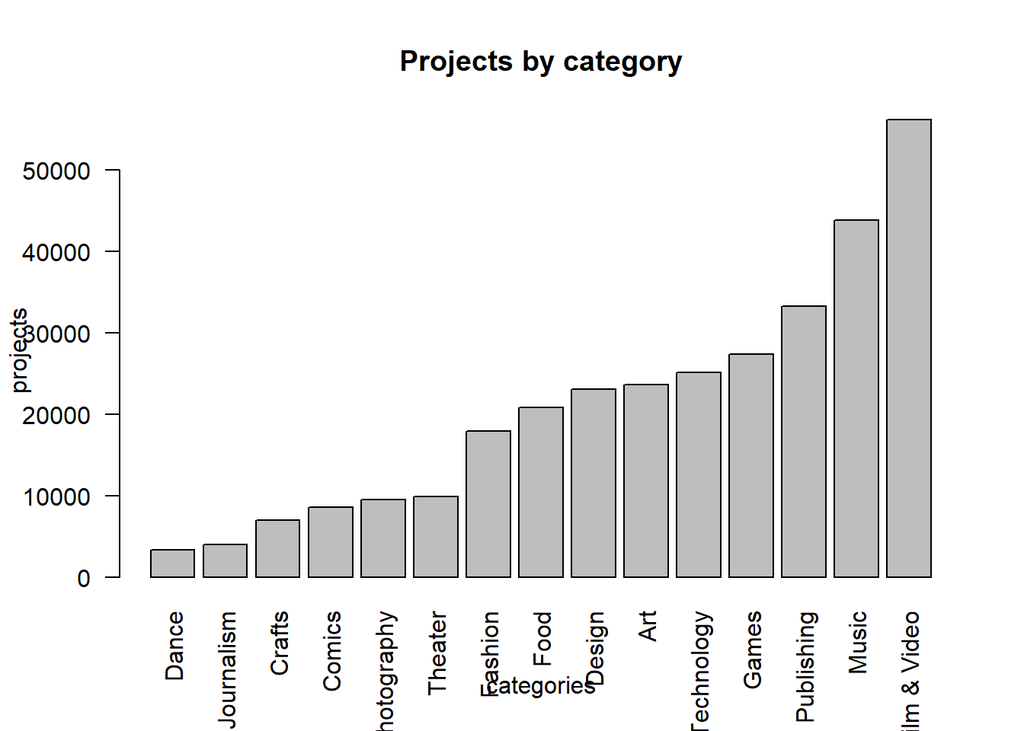

```r
data %>%
  group_by(main_category) %>%
  summarise(projects = n()) %>%
  arrange(projects) %>%
  with(barplot(projects, names.arg = main_category, xlab = "categories", ylab = "projects", main = "Projects by category", las = 2))
```

### Projects by year

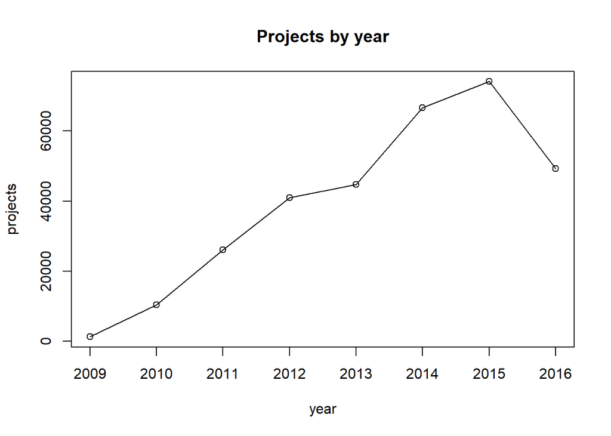

```r
data %>%
  mutate(year = as.integer(format(launched, "%Y"))) %>%
  group_by(year) %>%
  summarise(projects = n()) %>%
  arrange(year) %>%
  with(plot(year, projects, type = "o", main = "Projects by year"))
```

### Projects by month

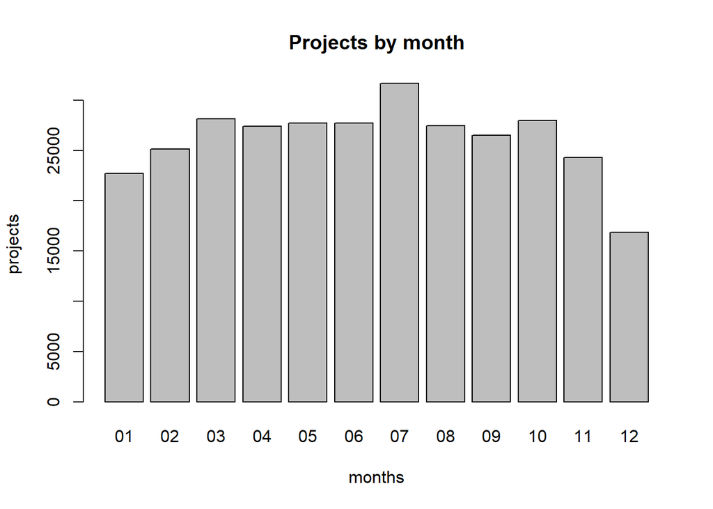

```r
data %>%
  mutate(month = format(launched, "%m")) %>%
  group_by(month) %>%
  summarise(projects = n()) %>%
  arrange(month) %>%
  with(barplot(projects, names.arg = month, xlab = "months", ylab = "projects", main = "Projects by month"))
```

### Projects by state

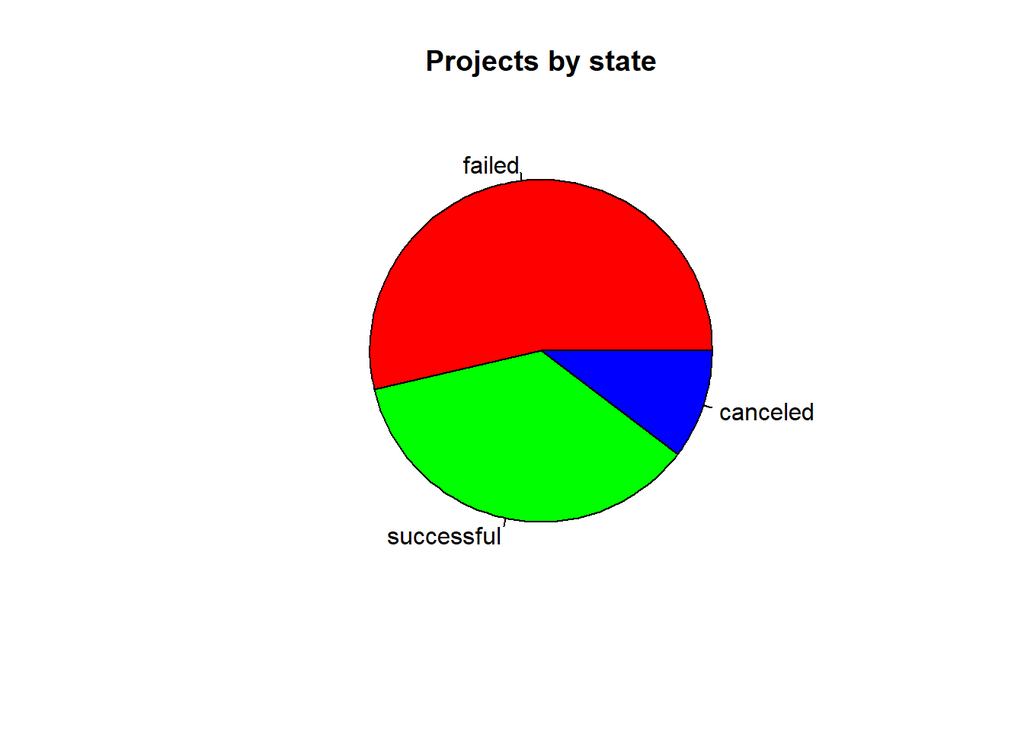

```r
data %>%
  group_by(state) %>%
  summarise(projects = n()) %>%
  arrange(desc(projects)) %>%
  with(pie(projects, state, col = rainbow(length(projects)), main = "Projects by state"))
```

### Goal amount boxplot

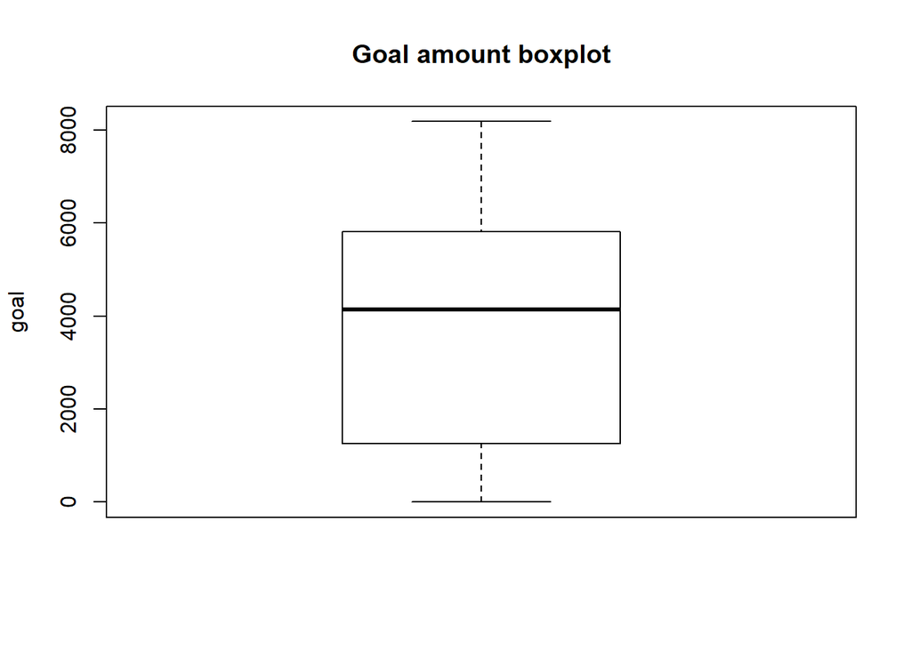

```r
boxplot(data$goal, ylab = "goal", main = "Goal amount boxplot")
```

### Projects by goal amount

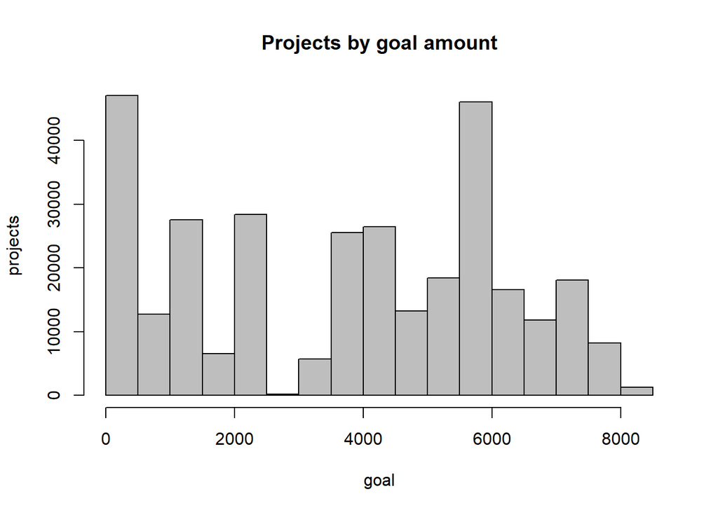

```r
hist(data$goal, xlab = "goal", ylab = "projects", main = "Projects by goal amount", col = "grey")
```

### Pledged amount boxplot

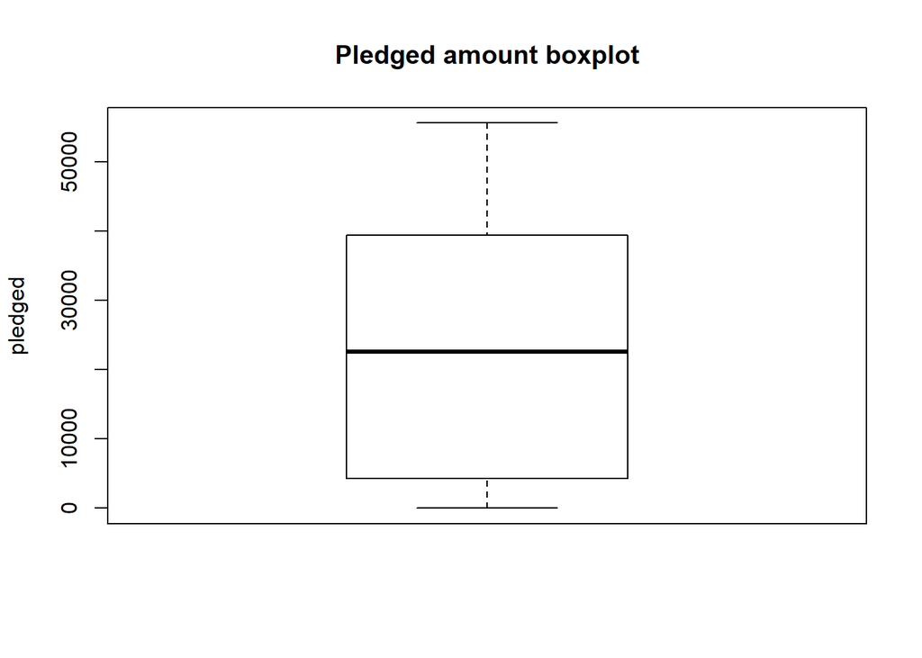

```r
boxplot(data$pledged, ylab = "pledged", main = "Pledged amount boxplot")
```

### Projects by pledged amount

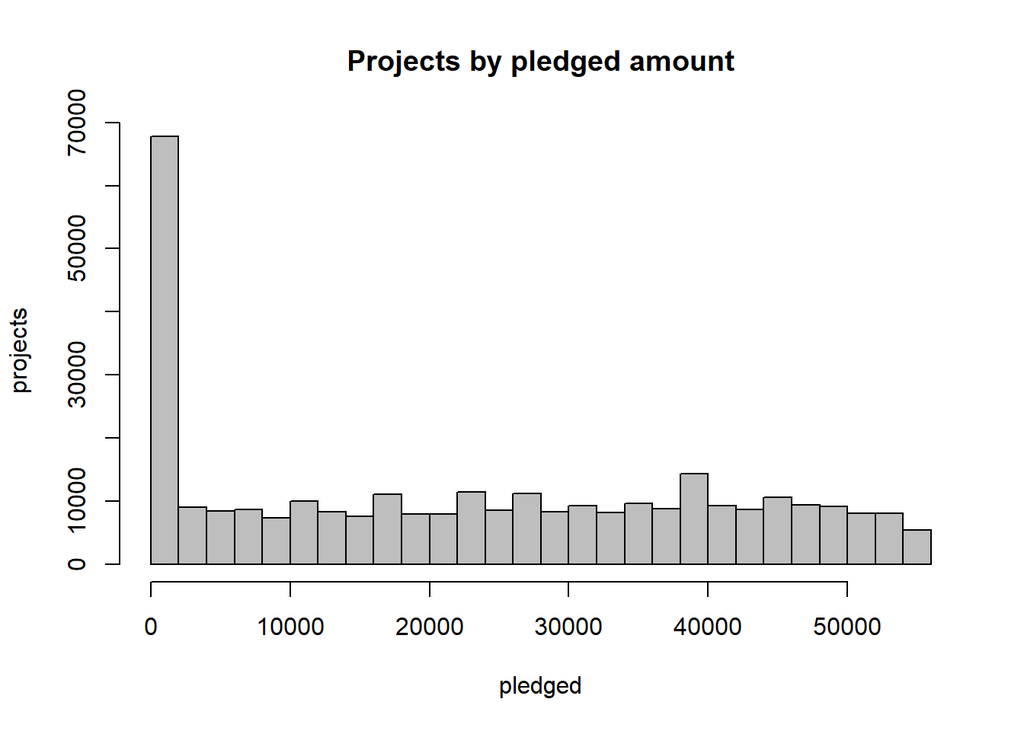

```r
hist(data$pledged, xlab = "pledged", ylab = "projects", main = "Projects by pledged amount", col = "grey")
```

### Backers number boxplot

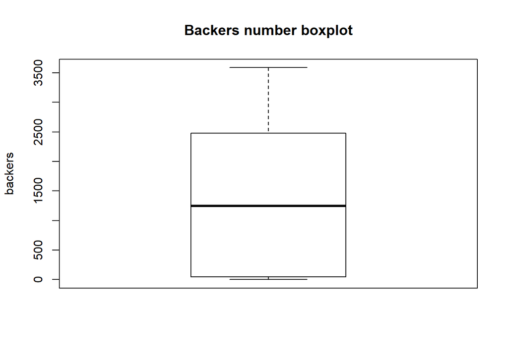

```r
boxplot(data$backers, ylab = "backers", main = "Backers number boxplot")
```

### Projects by backers number

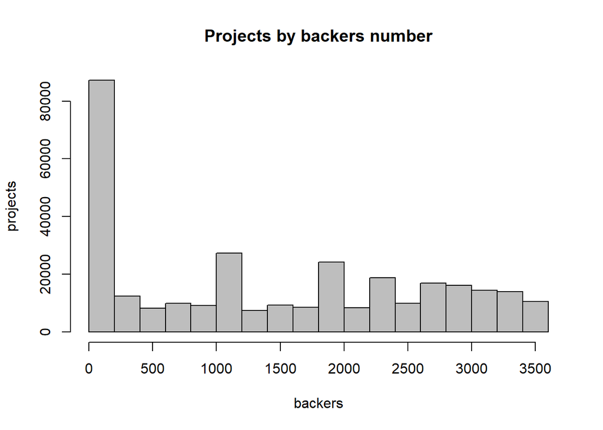

```r
hist(data$backers, xlab = "backers", ylab = "projects", main = "Projects by backers number", col = "grey")
```

## Multivariate analysis

Now we will take a closer look at the data, taking into consideration two or more features at the time, so that we can observe trends and dependencies.

### Project state by category

```r
data %>%
  group_by(main_category) %>%
  summarise(sucessfull = sum(state == "successful"),
            failed = sum(state == "failed"),
            canceled = sum(state == "canceled"),
            success_rate = round(sum(state == "successful") / n(), digits = 2),
            failed_rate = round(sum(state == "failed") / n(), digits = 2),
            canceled_rate = round(sum(state == "canceled") / n(), digits = 2))
```

```
## # A tibble: 15 x 7
##    main_category sucessfull failed canceled success_rate failed_rate
##    <fct>              <int>  <int>    <int>        <dbl>       <dbl>
##  1 Art                 9654  12092     1884         0.41        0.51
##  2 Comics              4499   3406      702         0.52        0.4
##  3 Crafts              1671   4630      682         0.24        0.66
##  4 Dance               2101   1089      137         0.63        0.33
##  5 Design              7959  12039     3118         0.34        0.52
##  6 Fashion             4310  11500     2128         0.24        0.64
##  7 Film & Video       21404  29653     5160         0.38        0.53
##  8 Food                5256  13602     1933         0.25        0.65
##  9 Games               9385  13013     4967         0.34        0.48
## 10 Journalism           869   2657      435         0.22        0.67
## 11 Music              21763  19193     2938         0.5         0.44
## 12 Photography         2903   5743      884         0.3         0.6
## 13 Publishing         10255  19920     3085         0.31        0.6
## 14 Technology          5062  16347     3749         0.2         0.65
## 15 Theater             5990   3337      546         0.61        0.34
## # ... with 1 more variable: canceled_rate <dbl>
```

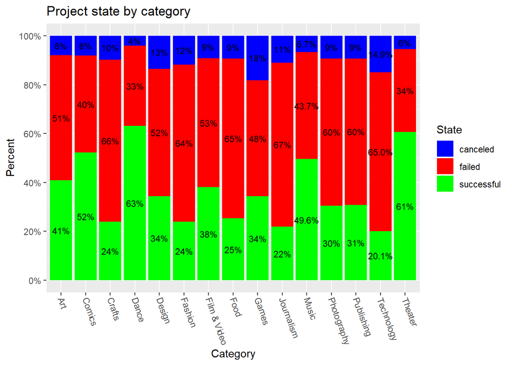

```r
plot1 <- data %>%
  group_by(main_category, state) %>%
  summarise(count = n()) %>%
  mutate(percentage = count / sum(count), label = scales::percent(percentage))

ggplot(plot1, aes(x = factor(main_category, levels = levels(plot1$main_category)),
                  y = percentage,
                  fill = factor(state, levels = levels(plot1$state)))) +
  geom_bar(stat = "identity", position = "fill") +
  scale_y_continuous(breaks = seq(0, 1, 0.2), labels = paste(seq(0, 100, 20), "%", sep = "")) +
  geom_text(aes(label = label), size = 3, position = position_stack(vjust = 0.5)) +
  scale_fill_manual(values = c("successful" = "green", "failed" = "red", "canceled" = "blue")) +
  labs(y = "Percent", fill = "State", x = "Category", title = "Project state by category") +
  theme(axis.text.x = element_text(angle = 290, hjust = 0, vjust = 0.5))
```

First we took a look at the number of successful, failed and canceled projects for each category. This gives us an insight into what is the rate of successful and unsuccessful projects with respect to project category. Moreover, those values can give an information about the probability that a project in given category will suceeed.

We can see that projects associated with Dance and Theater categories have the highest, more that 60% chance of success. On the other end of the spectrum we have technology projects with just over 20% chance of success, which is probably both higly competitive and saturated industry with crowdfunded projects recently. Also high chance of failure have projects related to Journalism, Crafts and Fashion. Interestingly, Game projects have the highest chance of getting cancelled.

### Project state by year

```r
data %>%
  mutate(year = as.integer(format(launched, "%Y"))) %>%
  group_by(year) %>%
  summarise(sucessfull = sum(state == "successful"),
            failed = sum(state == "failed"),
            canceled = sum(state == "canceled"),
            success_rate = round(sum(state == "successful") / n(), digits = 2),
            failed_rate = round(sum(state == "failed") / n(), digits = 2),
            canceled_rate = round(sum(state == "canceled") / n(), digits = 2)) %>%
  arrange(year)
```

```
## # A tibble: 8 x 7
##    year sucessfull failed canceled success_rate failed_rate canceled_rate
##   <int>      <int>  <int>    <int>        <dbl>       <dbl>         <dbl>
## 1  2009        576    598      150         0.44       0.45           0.11
## 2  2010       4585   4965      925         0.44       0.47           0.09
## 3  2011      12152  11839     2139         0.47       0.45           0.08
## 4  2012      17866  20544     2626         0.44       0.5            0.06
## 5  2013      19388  21627     3680         0.43       0.48           0.08
## 6  2014      21076  38103     7403         0.32       0.570          0.11
## 7  2015      20943  44231     8911         0.28       0.6            0.12
## 8  2016      16495  26314     6514         0.33       0.53           0.13
```

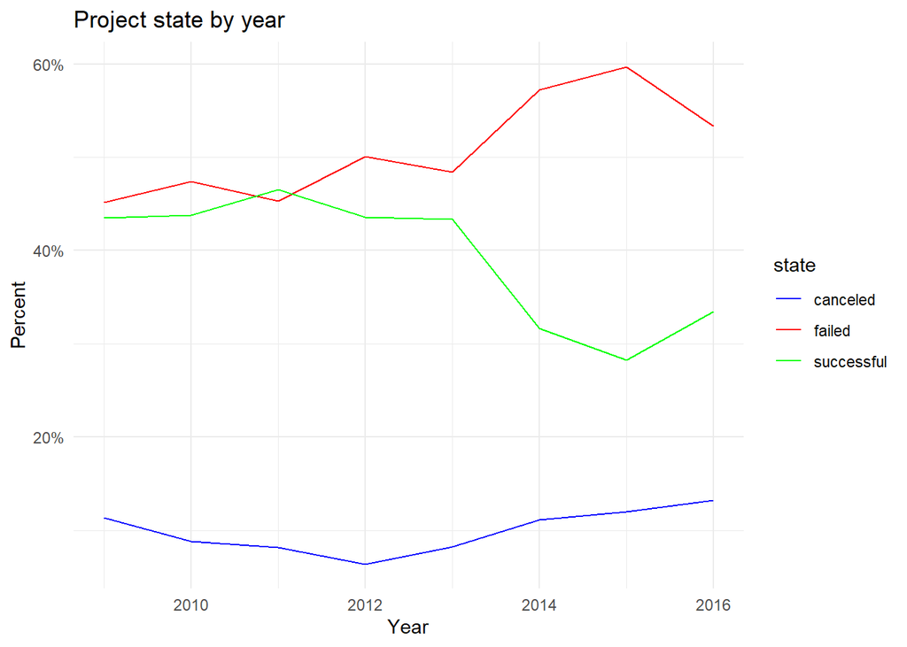

```r
plot2 <- data %>%
  mutate(year = as.integer(format(launched, "%Y"))) %>%
  group_by(year, state) %>%
  summarise(count = n()) %>%
  mutate(percentage = count / sum(count), label = scales::percent(percentage)) %>%
  arrange(year)

ggplot(plot2, aes(x = year, y = percentage)) +
  geom_line(aes(color = state)) +
  scale_color_manual(values = c("successful" = "green", "failed" = "red", "canceled"="blue")) +
  scale_y_continuous(breaks = seq(0, 1, 0.2), labels = paste(seq(0, 100, 20), "%", sep = "")) +
  labs(y = "Percent", fill = "State", x = "Year", title = "Project state by year") +
  theme_minimal()
```

We can also observe how projects states changed over time, which can give us information on both the performance of the platform, good preparation and execution of the projects and overall interest in such form of projects support. We can quite clearly see changing trends, with the most notable raise in the number of unsuccessful projects up until the year 2015, to almost 60%. There has also been a gradual increase in the number of cancelled projects.

Overall, we can claim that in the years 2009-2016 probably the best time to start a crowdfunding project on Kickstarter was year 2011, where there wa roughly 50% chance for success as well as for the failure.

### Project state by month

```r
data %>%
  mutate(month = as.integer(format(launched, "%m"))) %>%
  group_by(month) %>%
  summarise(sucessfull = sum(state == "successful"),
            failed = sum(state == "failed"),
            canceled = sum(state == "canceled"),
            success_rate = round(sum(state == "successful") / n(), digits = 2),
            failed_rate = round(sum(state == "failed") / n(), digits = 2),
            canceled_rate = round(sum(state == "canceled") / n(), digits = 2)) %>%
  arrange(month)
```

```
## # A tibble: 12 x 7
##    month sucessfull failed canceled success_rate failed_rate canceled_rate
##    <int>      <int>  <int>    <int>        <dbl>       <dbl>         <dbl>
##  1     1       7859  12616     2250         0.35       0.56           0.1
##  2     2       9500  13162     2483         0.38       0.52           0.1
##  3     3      10792  14594     2776         0.38       0.52           0.1
##  4     4      10444  14232     2750         0.38       0.52           0.1
##  5     5      10298  14529     2878         0.37       0.52           0.1
##  6     6      10128  14800     2796         0.37       0.53           0.1
##  7     7      10178  18098     3404         0.32       0.570          0.11
##  8     8       9212  15324     2920         0.34       0.56           0.11
##  9     9       9636  14146     2716         0.36       0.53           0.1
## 10    10      10407  14491     3061         0.37       0.52           0.11
## 11    11       8867  12807     2614         0.37       0.53           0.11
## 12    12       5760   9422     1700         0.34       0.56           0.1
```

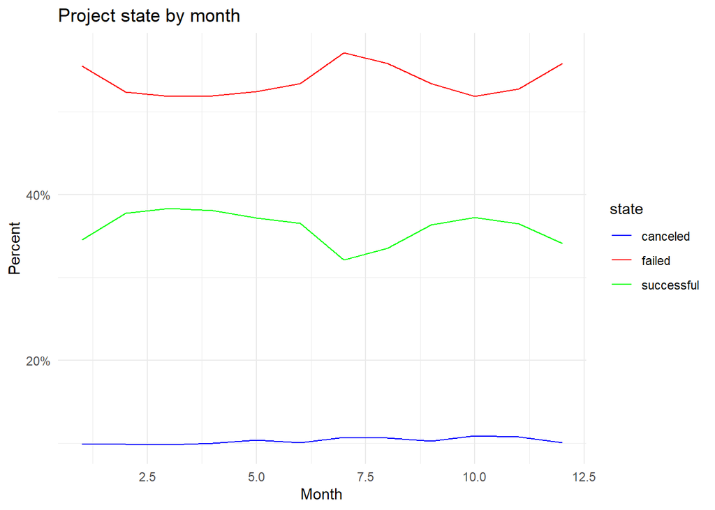

```r
plot3 <- data %>%
  mutate(month = as.integer(format(launched, "%m"))) %>%
  group_by(month, state) %>%
  summarise(count = n()) %>%
  mutate(percentage = count / sum(count), label = scales::percent(percentage)) %>%
  arrange(month)

ggplot(plot3, aes(x = month, y = percentage)) +
  geom_line(aes(color = state)) +
  scale_color_manual(values = c("successful" = "green", "failed" = "red", "canceled" = "blue")) +
  scale_y_continuous(breaks = seq(0, 1, 0.2), labels = paste(seq(0, 100, 20), "%", sep = "")) +
  labs(y = "Percent", fill = "State", x = "Month", title = "Project state by month") +
  theme_minimal()
```

### Goal amount by category and state

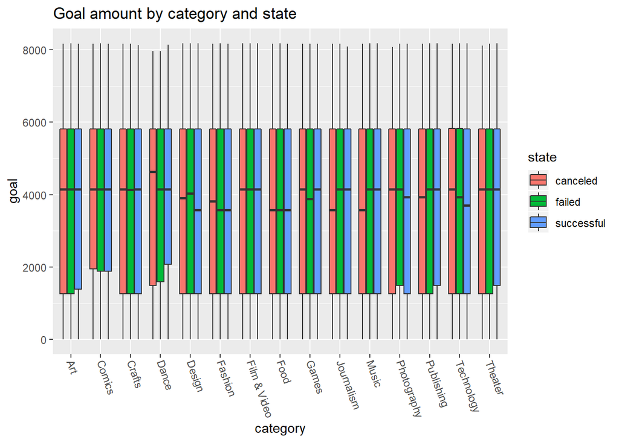

```r
ggplot(data, aes(x = main_category, y = goal, fill = state)) +
  geom_boxplot() +
  labs(fill = "Goal") +
  labs(y = "goal", fill = "state", x = "category", title = "Goal amount by category and state") +
  theme(axis.text.x = element_text(angle = 290, hjust = 0, vjust = 0.5))
```

Next, we wanted to see if there is any correlation between project category and the disctibution of goal, which is the amount of money project owner would like to gather. As we can see, values across most of the categories are uniorm with a few exceptions when it comes to median value.

### Pledged amount by category and state

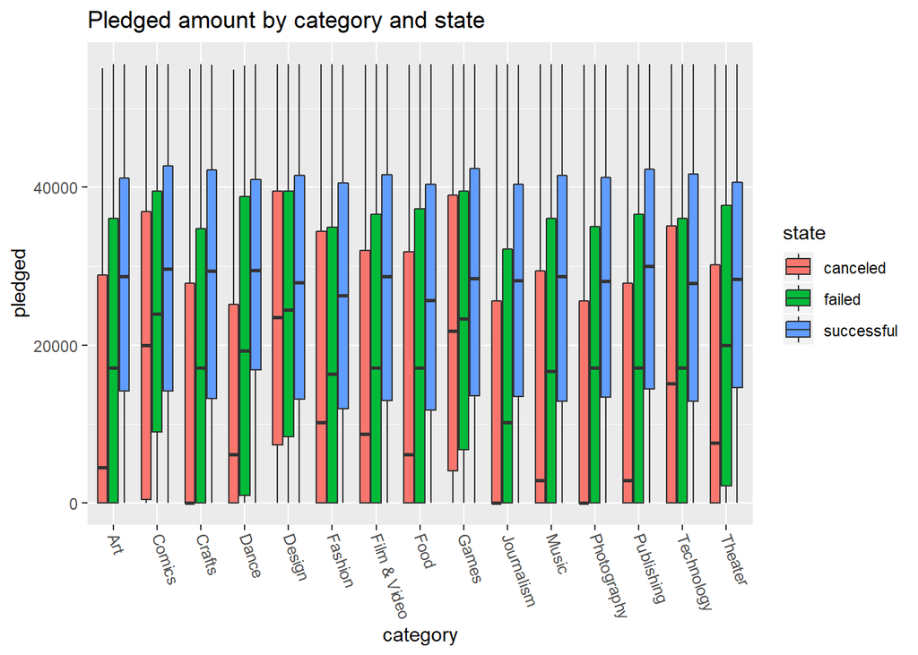

```r
ggplot(data, aes(x = main_category, y = pledged, fill = state)) +
  geom_boxplot() +
  labs(fill = "Pledged") +
  labs(y = "pledged", fill = "state", x = "category", title = "Pledged amount by category and state") +
  theme(axis.text.x = element_text(angle = 290, hjust = 0, vjust = 0.5))
```

Contrary to the previous chart, we can see certain dependencies on this one. First thing is that, naturally, successful projects have highest pledged amounts, followed by failed and cancelled projects. We can observe that across all categories.

Looking deeper, typically here is a significant difference between the median for projects that have been cancelled and have failed. Exceptions to that rule would be Technology, Games and Design, where the distributions of pledged amout for cancelled and failed projects overlap. Design is the most interesing category amongs all in this regard, because as we can see on the chart, there is very little dependence in projects status on the amount that has actually been raised by the project owner.

### Backers number by category and state

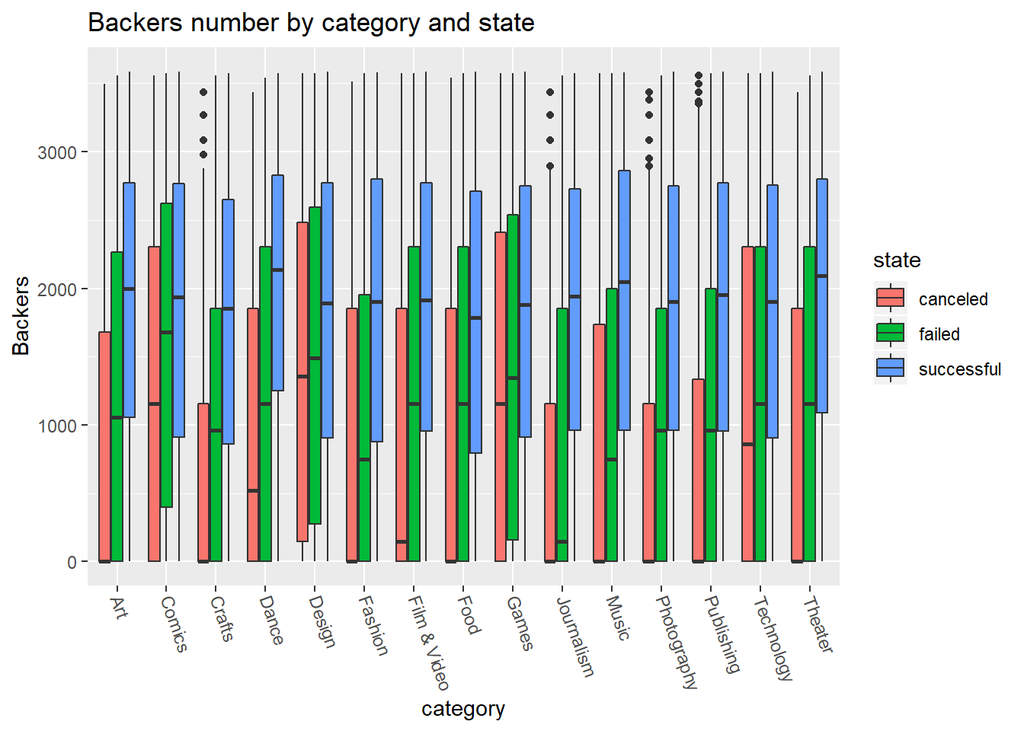

```r
ggplot(data, aes(x = main_category, y = backers, fill = state)) +
  geom_boxplot() +
  labs(fill = "Backers") +
  labs(y = "Backers", fill = "state", x = "category", title = "Backers number by category and state") +
  theme(axis.text.x = element_text(angle = 290, hjust = 0, vjust = 0.5))
```

### Project state by goal amount

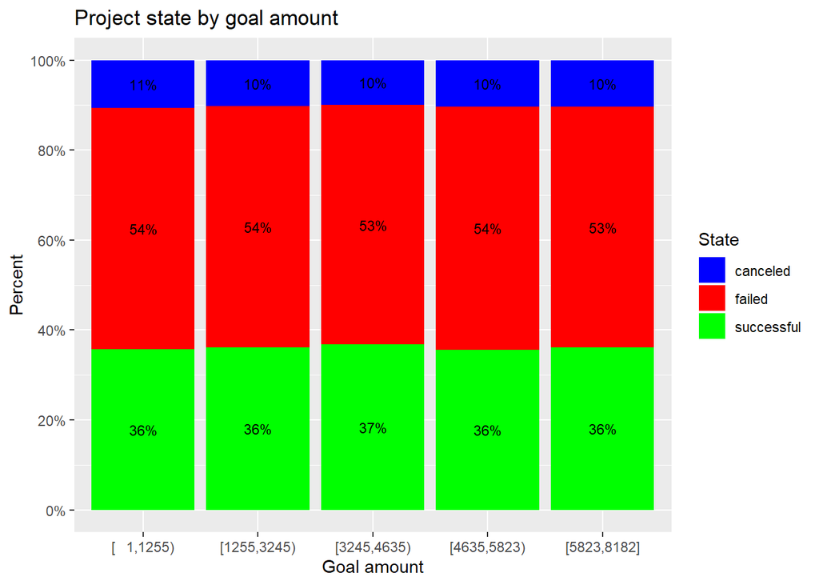

```r
getGroupNumber <- function(x) {
  sapply(x, function(x) {
    if      (x >= 0    & x < 1255) return(0)
    else if (x >= 1255 & x < 3245) return(1)
    else if (x >= 3245 & x < 4635) return(2)
    else if (x >= 4635 & x < 5823) return(3)
    else                           return(4)
  })
}

plot5 <- data %>%
  mutate(bin = as.factor(getGroupNumber(goal))) %>%
  group_by(bin, state) %>%
  summarise(count = n()) %>%
  mutate(percentage = count / sum(count), label = scales::percent(percentage))

ggplot(plot5, aes(x = factor(bin, levels = levels(plot5$bin), labels = levels(cut2(data$goal, g = 5))),
                  y = percentage,
                  fill = factor(state, levels = levels(plot5$state)))) +
  geom_bar(stat = "identity", position = "fill") +
  scale_y_continuous(breaks = seq(0, 1, 0.2), labels = paste(seq(0, 100, 20), "%", sep = "")) +
  geom_text(aes(label = label), size = 3, position = position_stack(vjust = 0.5)) +
  scale_fill_manual(values = c("successful" = "green", "failed" = "red", "canceled" = "blue")) +
  labs(y = "Percent", fill = "State", x = "Goal amount", title = "Project state by goal amount")
```

As the last thing, we decided to examine if we there is any relation between the project goal and the state (for instace if projects with lower goal had a higher chance of success or not). As we can see, correlation between the project state and the goal isn’t apparent.